# Higher Moments Of Observables in a Non-Linear Kerr Medium

Here the codes and the resulting plots for the observables and their combinations for a Kerr medium are given. The Hamiltonian for the system is given by:

$$ H = \hbar\chi(a^{\dagger 2} a^2) $$

where $a$ and $a^{\dagger}$ are the **lowering** and **raising** operators (conversely called as **annihilation** and **creation** operators when used in *Quantum Optics*), and they are given as, $$a = x + ip_x$$ $$a^{\dagger} = x - ip_x$$

We would like to recall that a certain superposition of states in a system, act as a eigen state to the lowering operator $a$, and we call this superposition state, the coherent state |$\psi_{\alpha}$> $$a |\alpha> = \alpha |\alpha>$$ where $\alpha$ is some complex number, a consequence of **a** being a non-hermitian eigen operator of the coherent state.

The time dependent coherent state $|\alpha (t)>$ is given as: $$|\alpha (t)> = e^{- \dfrac{|{\alpha^2}|}{2}} \sum_{n=0}^\infty \dfrac{\alpha^{n}}{\sqrt{n!}} e^{\dfrac{-iHt}{\hbar}}|n>$$

The general formula to find $<a>$ and $<a^{\dagger}>$ or any combination, $<a^{\dagger r} a^{r + s}>$ can be derived "easily" by the formula:

$$<a^{\dagger r} a^{r + s}> = \alpha^s \nu^r e^{-\nu (1 - cos2\chi st)} exp\{-i\chi (l(l - 1) + 2rs)t - i\nu sin2\chi st\} . . . . (1)$$

Here $\nu = |\alpha|^2$,which we will henceforth refer to with the latter notation ($|\alpha|^2$) to avoid any confusion. We conveniently define $\alpha = \frac{p_1 + i q_1}{\sqrt{2}}$ , which subsequently means that $|\alpha|^2 = \frac{(p_1^2 + q_1^2)}{2}$

## Average of position as a function of time.

The average position with respect to time $<x(t)>$ can be obtained by noting that we get $<a>$ by setting **r = 0** and **s = 1** in **(1)**, whereupon ,we get

$$<a(t)> = \alpha e^{- |\alpha|^2 (1 - cos2\chi t)} exp\{-i|\alpha|^2 sin2 \chi t\}$$

$$<x(t)> = e^{- |\alpha|^2 (1-cos(2\chi t)} [p_1 cos(|\alpha|^2 sin2\chi t)+q_1sin(|\alpha|^2 sin2\chi t)]$$

```python
import matplotlib.pyplot as plt
import warnings
import numpy as np
warnings.filterwarnings("ignore")
```

Let's set $\chi$ to be some positive constant. In our case,we will call it **' f '** and we have set it to be 5.

The value alpha which is the eigen value of the eigen state ket ${\alpha}$, can be written as $p_1 + i q_1$. By changing the values of $p_1$ and $q_1$, we can essentially change the way the "system" behaves. Initially, let us set $p_1$ and $q_1$ to be equal to 1.

## **We can change the parameters here.**

> > *To add squareroot values, use the keyword "np.sqrt(num)"*

For example, to store the $\sqrt{10}$ in p1, we write:

p1 = np.sqrt(10)

```python
f = 5
p1 = 1
q1 = 1

reg = 0.5 * np.pi
```

Next, we create arrays to store the position values. We will call it, for the lack of a better name *posx*. Let us define a function *avgx*, that takes in the values of p1,q1 and stores the **"average of x"** in an array.

`def avgx(p1,q1,array to store the values in)`

We call the function once by giving the function **avgx** the parameters, p1,q1, and the posx array, to store the values.Next, we plot the values.

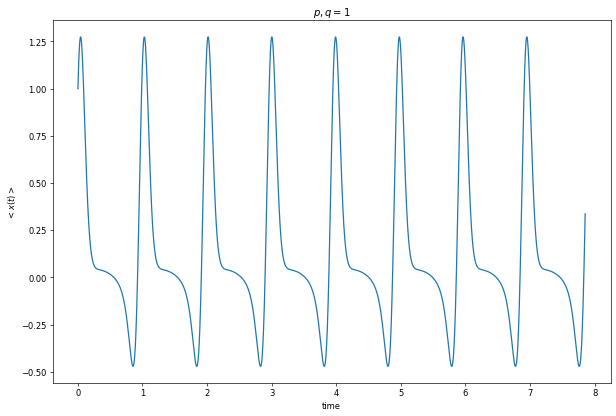

```python
posx = []

def avgx(p,q,somearray):
  for t in np.arange(0,5,0.0001):
    mod = p**2 + q**2
    m = np.exp(-1 * mod * (1 - np.cos(2 * f * t)))
    a = p * (np.cos(mod * np.sin(2 * f * t)))
    b = q * (np.sin(mod * np.sin(2 * f * t)))

    final = m * (a + b)

    somearray.append(final)

time = np.linspace(0, 5 * reg, 50000)

avgx(p1, q1, posx)

plt.plot(time,np.array(posx))
plt.xlabel("time")
plt.ylabel(r"$<x(t)>$")
plt.title(r"$p,q = 1$")
plt.show()
```

we plot the same for $p_1 = \sqrt{10}$ and $q_1 = \sqrt{10}$ , and find that the peaks have become more prominent.

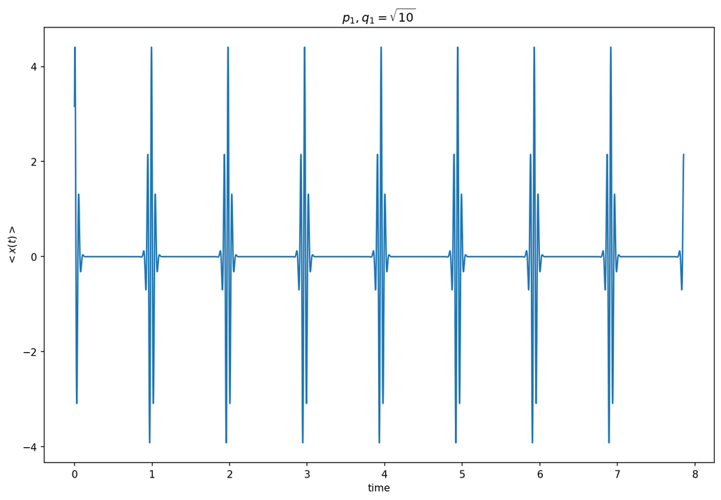

```python
pos1x = []

avgx(np.sqrt(10),np.sqrt(10), pos1x)

plt.plot(time,np.array(pos1x))
plt.xlabel("time")
plt.ylabel(r"$<x(t)>$")
plt.title(r"$p_1,q_1 = \sqrt{10} $")
plt.rcParams['figure.dpi'] = 150
plt.show()
```

Subsequently , we find that the plot now shows very impressive signatures at those times, when revival takes place, and the signatures become markedly distinct as we increase $\nu$ or in other words, $(p^2_1 + q_1^2)$. In the next plot we have fixed the values of $p_1$ and $q_1$ to be 10.

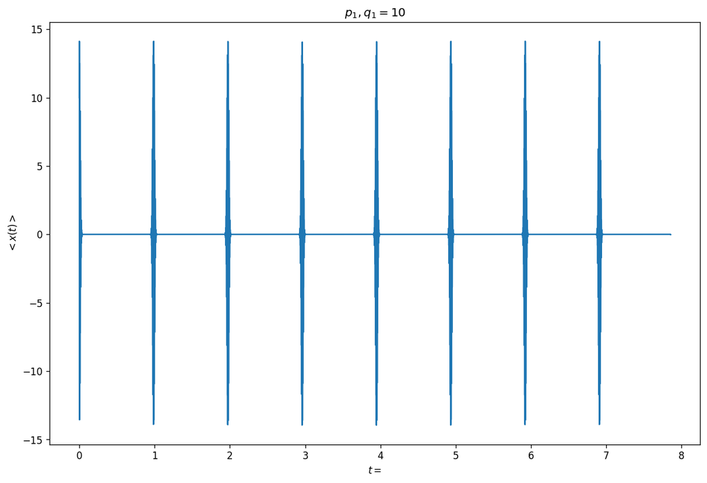

```python
pos2x = []

avgx(10,10, pos2x)

plt.plot(time,np.array(pos2x))
plt.xlabel("$t = \frac{\chi t}{\pi}$")
plt.ylabel(r"$<x(t)>$")
plt.title(r"$p_1,q_1 = 10 $")
plt.rcParams['figure.figsize'] = [12,8]
plt.rcParams['figure.dpi'] = 150
plt.show()
```

## Average of Momentum as a function of time.

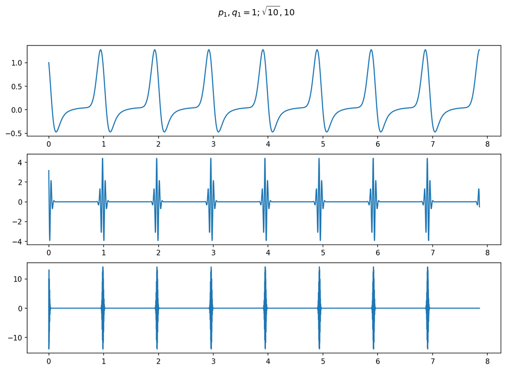

```python
momx = []
mom2x = []
mom3x = []

warnings.simplefilter(action='ignore', category=FutureWarning)

time2 = np.linspace(0,5 * reg,50000)

def avgp(p,q,somearray):
  for t in np.arange(0,5,0.0001):
    mod = p**2 + q**2
    ins = np.sin(2 * f * t)
    a = np.exp(-mod * (1 - np.cos(2 * f * t)))
    fin = a * (-p * np.sin(mod * ins) + q * np.cos(mod * ins))
    somearray.append(fin)


avgp(p1,q1,momx)
avgp(np.sqrt(10),np.sqrt(10),mom2x)
avgp(10,10,mom3x)

fig ,((ax1) ,(ax2) ,(ax3)) = plt.subplots(3, 1)
ax1.plot(time2, momx)
plt.suptitle(r"$p_1,q_1 = 1 ; \sqrt{10}, 10$")
ax2.plot(time2, mom2x)
ax3.plot(time2, mom3x)
plt.show()
```

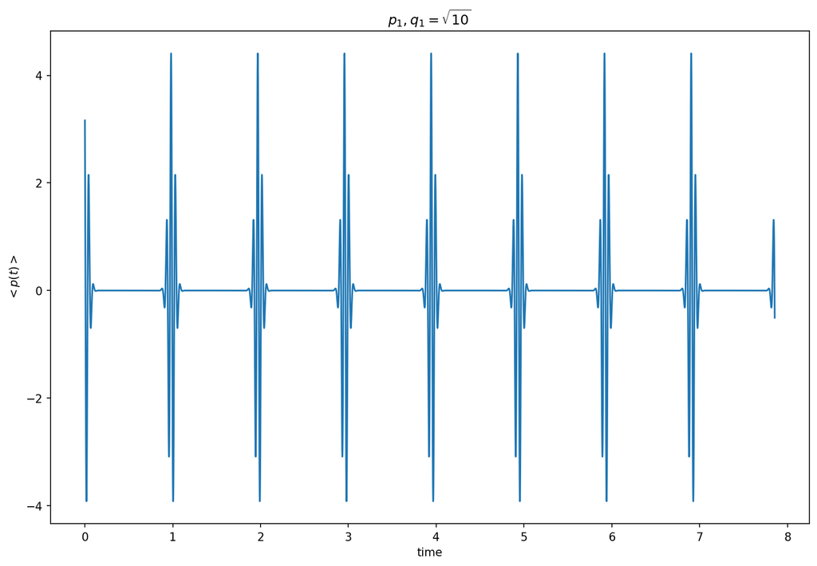

```python
mom2x = []
avgp(np.sqrt(10),np.sqrt(10),mom2x)
plt.plot(time2,mom2x)
plt.xlabel("time")
plt.ylabel(r"$<p(t)>$")
plt.title(r"$p_1,q_1 = \sqrt{10}$")
plt.show()
```

These show a very sharp peak at regular intervals, which are multiples of the revival time $T_{rev}$. These peaks become more prominent as the value of $\nu$ increases.

## For higher moments of x and p.

Similarly, for higher moments of x and p, we would like to plot their values with respect to time, for which we can employ the above given formula. We find that $<x^2(t)>$ is:

$$<x^2(t)> = \frac{1}{2} \{1 + p_1^2 + q_1^2 + e^{-(p_1^2 + q_1^2)(1 - cos4\chi t)} [(p_1^2 - q_1^2)cos(2\chi t + (p^2_1 + q^2_1)sin4\chi t)+ 2p_1q_1sin(2\chi t+(p_1^2 + q_1^2)sin4\chi t]\}$$

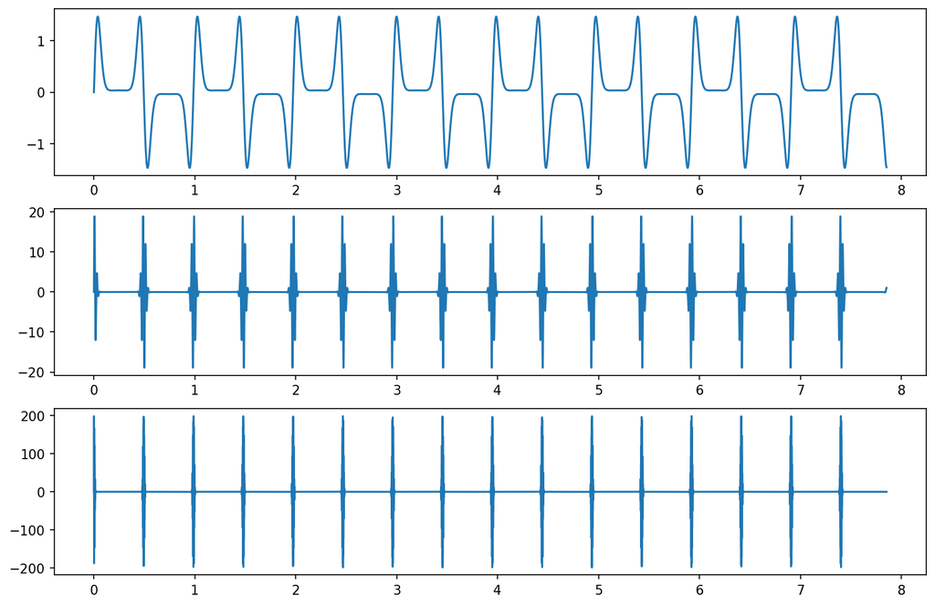

```python
xsq1 = []
xsq2 = []
xsq3 = []

def x_sq(p,q,s):
    for t in np.arange(0,5,0.0001):
        plus = p**2 + q**2
        minus = p**2 - q**2
        a = np.exp(-1 * plus *(1 - np.cos(4 * f * t)))
        b = np.cos(2 * f * t + (plus * np.sin(4 * f * t)))
        c = np.sin(2 * f * t + (plus * np.sin(4 * f * t)))
        final = a * ((minus * a) + (2 * p * q * c))
        s.append(final)

x_sq(p1,q1,xsq1)
x_sq(np.sqrt(10),np.sqrt(10),xsq2)
x_sq(10,10,xsq3)
fig, ((ax1),(ax2),(ax3)) = plt.subplots(3,1)
ax1.plot(time, xsq1)
ax2.plot(time, xsq2)
ax3.plot(time, xsq3)
plt.show()
```

To find the value of $<L_x^2>$ we find that we can write $<L_x^2>$ as a function of $\beta$ and $\gamma$, where $\beta = r_2 e^{i\theta_2}$ and $\gamma = r_3 e^{i\theta_3}.$

[figure not shown]

```python
p2 = 1
q2 = 2
p3 = 1
q3 = 2

#def change_to_rtheta(p2,q2)

lx = []
lx2 = []
deltalx = []

def l_x(p2,q2,p3,q3,somearray):
    for t in np.arange(0,5,0.0001):
        bsq = p2**2 + q2**2
        gsq = p3**2 + q3**2
        a = np.exp(-1 * (bsq + gsq) * (1 - np.cos(2 * f * t)))
        b = ((p2 * p3) - (q2 * q3)) * np.cos((bsq - gsq) * (np.sin(2 * f * t)))
        c = ((p2 * q3) + (q2 * p3)) * np.sin((bsq - gsq) * (np.sin(2 * f * t)))
        final = a * (b + c)
        somearray.append(final)

l_x(p2,q2,p3,q3,lx)

def l_x_sq(p1,q1,p2,q2,somearray):
    theta2 = np.arctan(p2/q2)
    theta3 = np.arctan(p3/q3)
    r2 = (p2 * np.cos(theta2))**2 + (q2 * np.sin(theta2))**2
    r3 = (p3 * np.cos(theta3))**2 + (q3 * np.sin(theta3))**2
    for t in np.arange(0,5,0.0001):
        a = np.exp(-1 * (1 - np.cos(4 * f * t)) * (r2**2 + r3**2))
        ins = (p2**2) - (p3**2) - (2 * ((theta2 - theta3) * np.sin(4 * f * t)))
        final = -0.5 * (a * (2 * r2**2 * r3**2 * np.cos(ins)) - 2 * r2**2 * r3**2 - r2**2 - r3**2)
        somearray.append(final)


l_x_sq(p1,q1,p2,q2,lx2) # l x squared function

for i in range(len(lx)):
    if len(lx) == len(lx2):
        value = np.sqrt(lx2[i] - (lx[i]**2))
        deltalx.append(value)

fig ,((ax1),(ax2),(ax3),(ax4)) = plt.subplots(4,1)
ax1.plot(time,np.array(posx))
ax2.plot(time,np.array(lx))
ax3.plot(time,np.array(lx2))
ax4.plot(time,np.array(deltalx))

plt.show()
```

[Phase plot here](https://www.glowscript.org/#/user/p.b.ashish786/folder/MyPrograms/program/deltaxvsdeltap)